[OHI British Columbia](http://www.ohibc.org/) | [OHI Science](http://ohi-science.org) | [Citation policy](https://github.com/OHI-Science/ohiprep/releases)

# OHIBC: Fisheries modified Kobe plots

Compiled on Thu Dec 22 13:22:03 2016 by ohara

Kobe plot based upon B’ and F’, which are in turn based upon $F/F_{MSY}$ and $B/B_{MSY}$ relative to thresholds

$$x_{fis} = \displaystyle\sum_{i=1}^{n}w_i*\left(\frac{F' + B'}{2}\right)$$

- To calculate $B'$, we define categories in which a given stock is overfished, underfished, or adequately fished based on $B/B_{MSY}$. These are based on $B/B_{MSY}$ thresholds of $\theta_{OF}$ = 0.8 (overfished) and $\theta_{UF}$ = 1.5 (underfished):

| $B'$ calculation | Stock condition |
| --- | --- |
| $B' = \frac{B/B_{MSY}}{0.8}$ | Overfished ($B/B_{MSY} < \theta_{OF}$) |
| $B' = 1$ | Appropriately fished ($\theta_{OF} <= B/B_{MSY} < \theta_{UF}$) |
| $B' = \frac{(B/B_{MSY})_{max} - (B/B_{MSY})}{(B/B_{MSY})_{max} - 1.5}$ | Underfished ($B/B_{MSY} >= \theta_{UF}$) |

- To calculate F’, we examine fishing pressure within two regimes: overfished stock ($B/B_{MSY} < \theta_{OF}$) and not overfished stock ($B/B_{MSY} >= \theta_{OF}$). Within each regime we divide fishing pressure into overfishing, underfishing, and appropriate fishing pressures based on $F/F_{MSY}$, including under- and overfishing $F/F_{MSY}$ thresholds of $\psi_{UF}$ = 0.8 and $\psi_{OF}$ = 1.2, respectively.

| $F'$ calculation | Stock condition | Fishing pressure |
| --- | --- | --- |
| $F' = 0$ | Overfished | Gross overfishing ($F/F_{MSY} > B/B_{MSY} + 1.5$) |
| $F' = \frac{(B/B_{MSY} + 1.5) - F/F_{MSY}}{1.5}$ | Overfished | Moderate overfishing ($B/B_{MSY} + 0.2 < F/F_{MSY} <= B/B_{MSY} + 1.5$) |
| $F' = 1$ | Overfished | Appropriate fishing ($B/B_{MSY} - 0.2 <= F/F_{MSY} < B/B_{MSY} + 0.2$) |
| $F' = \frac{F/F_{MSY}}{B/B_{MSY} - 0.2}$ | Overfished | Underfishing ($F/F_{MSY} < B/B_{MSY} - 0.2$) |
| $F' = \frac{F/F_{MSY}}{\psi_{UF}}$ | *Not* overfished | Underfishing ($F/F_{MSY} < \psi_{UF}$) |
| $F' = 1$ | *Not* overfished | Appropriate fishing ($\psi_{UF} <= F/F_{MSY} < \psi_{OF}$) |
| $F' = \frac{(F/F_{MSY})_{max} - F/F_{MSY}}{(F/F_{MSY})_{max} - \psi_{OF}}$ | *Not* overfished | Overfishing ($F/F_{MSY} >= \psi_{OF}$) |

The following plots assume a local maximum (across all fisheries within region of study) $B/B_{MSY}$ of 3.5, and a local maximum $F/F_{MSY}$ of 2.5.

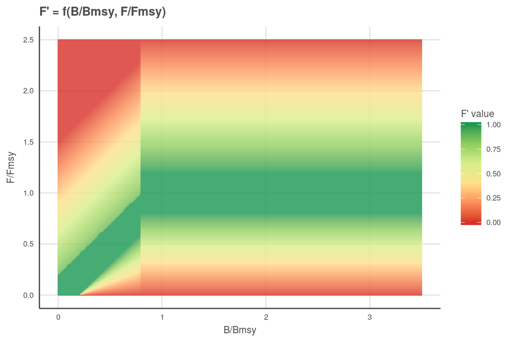

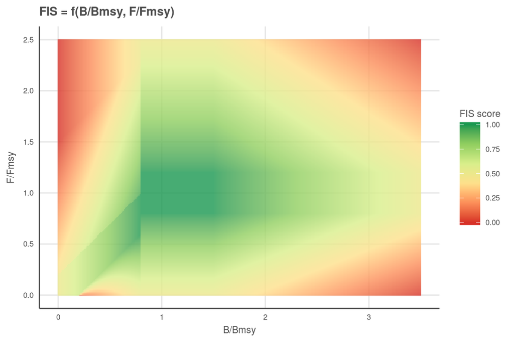

The following plots incorporate a “critical” zone for $B/B_{MSY}$ below which fishing is prohibited. BC Precautionary approach sets the critical value at 40% of $B_{MSY}$. For our calculations we will allow a -.1/+.3 tolerance around this to allow for uncertainty, though the tolerances can certainly be adjusted as necessary. The overfishing values will also be adjusted to drop to zero for all cases where B/Bmsy falls below (B/Bmsy critical - tolerance).

The following plots assume a local maximum (across all fisheries within region of study) $B/B_{MSY}$ of 3.5, and a local maximum $F/F_{MSY}$ of 2.5.

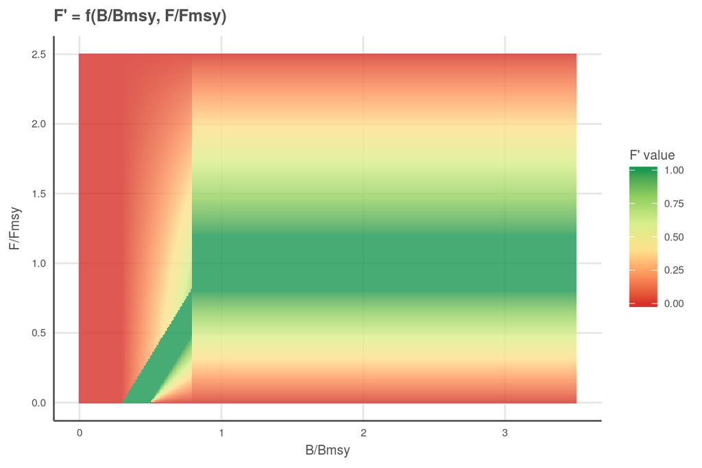

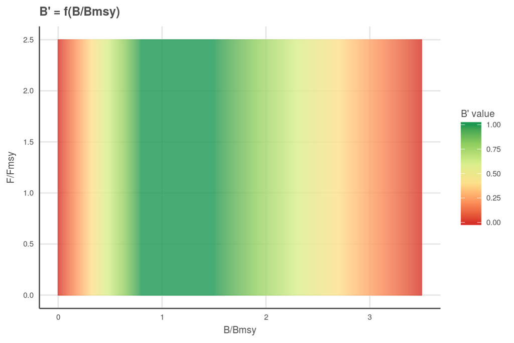

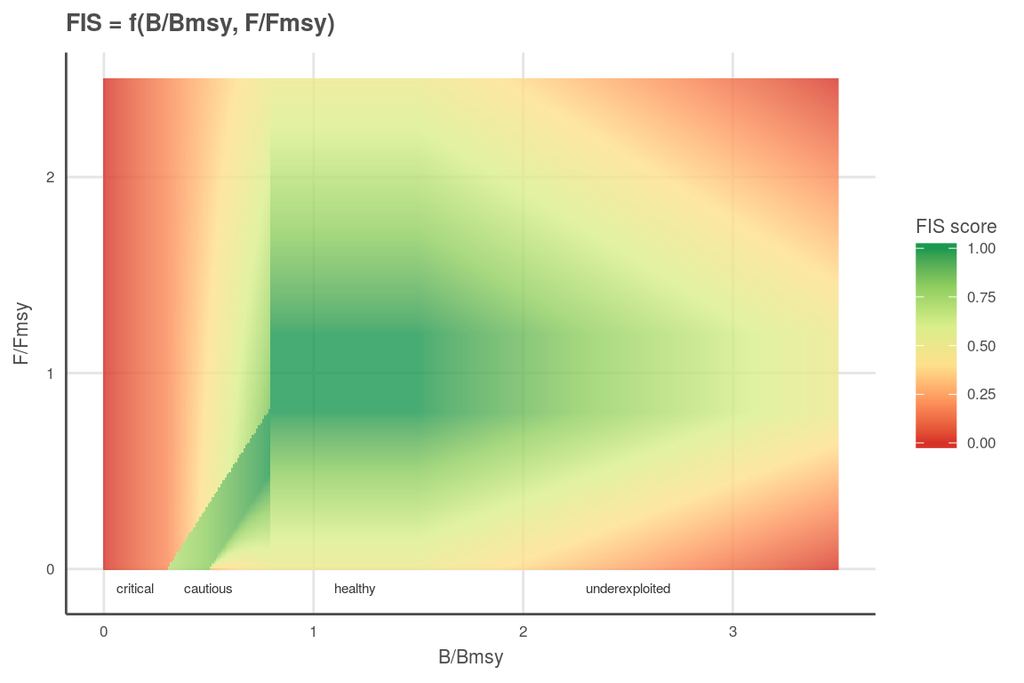

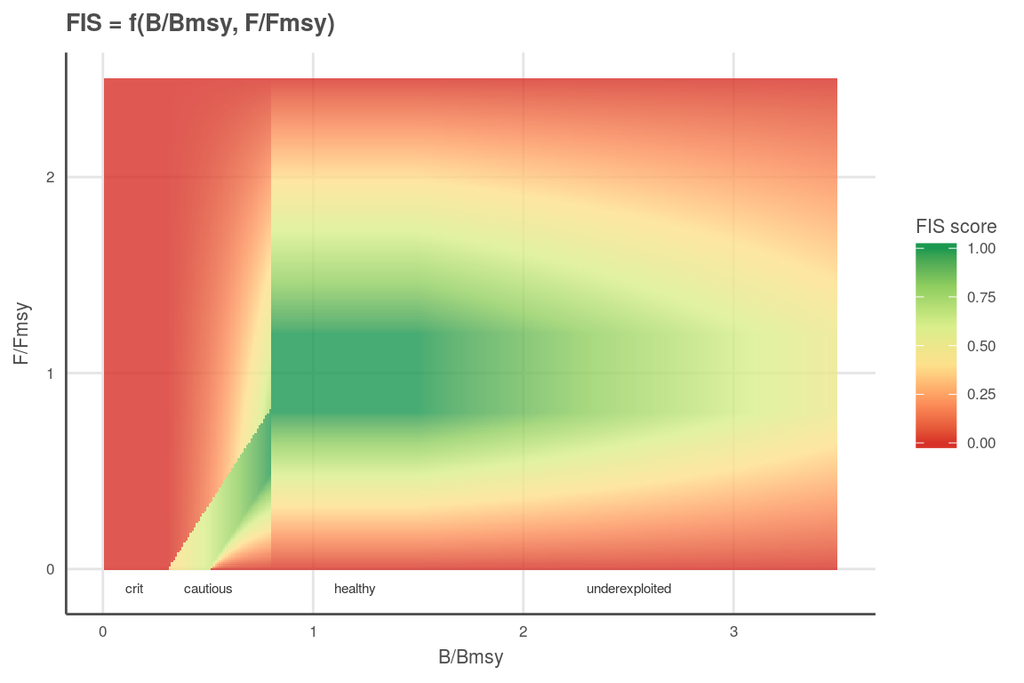